# Reproducible Research: Peer Assessment 1

## Loading and preprocessing the data

Load the data and transform date column to Date

```r
unzip('repdata_data_activity.zip', getwd())
activity_df = read.csv("activity.csv", header = T)
activity_df$date = as.Date(activity_df$date, "%Y-%m-%d")
```

## What is mean total number of steps taken per day?

For this part of the assignment, missing values are ignored in the dataset. Calculate the total number of steps taken per day

```r
total_step = tapply(activity_df$steps, as.factor(activity_df$date),sum)
```

Make a histogram of the total number of steps taken each day

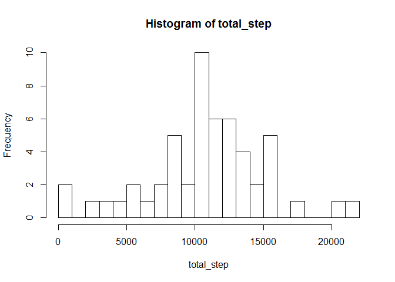

```r
hist(total_step, 20)
```

Calculate and report the mean and median of the total number of steps taken per day

```r
mean_total_step = mean(total_step, na.rm = T)
median_total_step = median(total_step, na.rm=T)
```

## What is the average daily activity pattern?

Make a time series plot (i.e. type = “l”) of the 5-minute interval (x-axis) and the average number of steps taken, averaged across all days (y-axis)

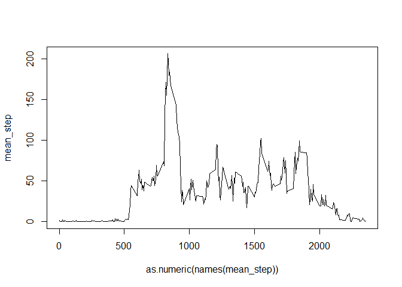

```r
mean_step = tapply(activity_df$steps, as.factor(activity_df$interval),function(x) mean(x,na.rm=T))
plot(as.numeric(names(mean_step)),mean_step, type="l")
```

Which 5-minute interval, on average across all the days in the dataset, contains the maximum number of steps?

```r
which.max(mean_step)
```

```
## 835
## 104
```

## Imputing missing values

Note that there are a number of days/intervals where there are missing values (coded as NA). The presence of missing days may introduce bias into some calculations or summaries of the data.

Calculate and report the total number of missing values in the dataset (i.e. the total number of rows with NAs)

```r
num_missing = sum(!complete.cases(activity_df))
```

total number of missing values in the dataset is 2304

Devise a strategy for filling in all of the missing values in the dataset: I am using the mean for that 5-minute interval to impute the value

```r
is_missing = !complete.cases(activity_df)
imputed_df = activity_df
imputed_df[is_missing, 'steps'] = mean_step[as.character(activity_df[is_missing,'interval'])]
```

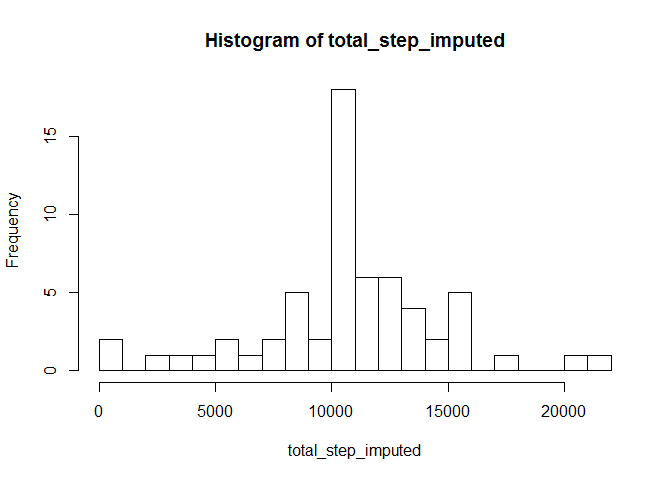

```r
total_step_imputed = tapply(imputed_df$steps, as.factor(imputed_df$date),sum)
hist(total_step_imputed, 20)
```

```r
mean_total_step_imputed = mean(total_step_imputed, na.rm = T)
median_total_step_imputed = median(total_step_imputed, na.rm=T)
```

## Are there differences in activity patterns between weekdays and weekends?

Create a new factor variable in the dataset with two levels - “weekday” and “weekend” indicating whether a given date is a weekday or weekend day.

```r
is_weekend = weekdays(imputed_df$date) %in% c('Saturday','Sunday')
imputed_df[is_weekend,"weekday"] = "weekend"
imputed_df[!is_weekend,"weekday"] = "weekday"
```

Make a panel plot containing a time series plot (i.e. type = “l”) of the 5-minute interval (x-axis) and the average number of steps taken, averaged across all weekday days or weekend days (y-axis).

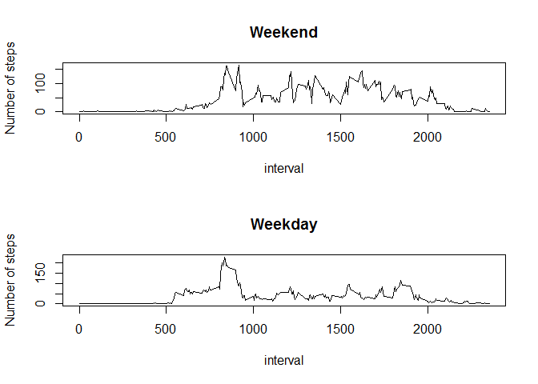

```r
mean_step_weekend = tapply(imputed_df[is_weekend,"steps"], as.factor(imputed_df[is_weekend,"interval"]),mean)
mean_step_weekday = tapply(imputed_df[!is_weekend,"steps"], as.factor(imputed_df[!is_weekend,"interval"]),mean)
par(mfrow = c(2,1))
plot(as.numeric(names(mean_step_weekend)),mean_step_weekend, type="l", main ="Weekend",
    xlab = "interval", ylab = "Number of steps")
plot(as.numeric(names(mean_step_weekday)),mean_step_weekday, type="l", main = "Weekday",
     xlab = "interval", ylab = "Number of steps")
```